# QALL401: Data Analysis for Researchers

## Course Contents

1. 2022.12.07: Introduction: About the course [lead by TK]
   - An introduction to open and public data, and data science
2. 2022-12-14: Exploratory Data Analysis (EDA) 1 [lead by hs]
   - R Basics with RStudio and/or RStudio.cloud; Toy Data
3. 2022-12-21: Exploratory Data Analysis (EDA) 2 [lead by hs]
   - R Markdown, `tidyverse` I: `dplyr`; `gapminder`
4. **2023-01-11: Exploratory Data Analysis (EDA) 3 [lead by hs]**
   - `tidyverse` II: `readr`, `ggplot2`; Public Data, WDI, WIR, etc
5. 2023-01-18: Exploratory Data Analysis (EDA) 4 [lead by hs]
   - `tidyverse` III: `tidyr`, etc.; WDI, WIR, etc
6. 2023-01-25: Exploratory Data Analysis (EDA) 5 [lead by hs]
   - `tidyverse` IV; WDI, WIR, etc
7. 2023-02-01: Introduction to PPDAC
   - Problem-Plan-Data-Analysis-Conclusion Cycle: [lead by TK]
8. 2023-02-08: Model building I [lead by TK]
   - Collecting and visualizing data and Introduction to WDI  
     (World Development Indicators by World Bank)
9. 2023-02-15: Model building II [lead by TK]
   - Analyzing data and communications
10. 2023-02-22: Project Presentation

## Exploratory Data Analysis (EDA) I

## Exploratory Data Analysis II

## Exploratory Data Analysis III

## Importing Public Data, WDI

### Reviews and Previews

```r
library(tidyverse)
library(gapminder)
library(maps)
library(WDI)
library(readxl)
library(ggrepel)
```

#### Gapminder Package Data

```r
df <- gapminder
df
```

| country | continent | year | lifeExp | pop | gdpPercap |
| --- | --- | --- | --- | --- | --- |
| Afghanistan | Asia | 1952 | 28.80100 | 8425333 | 779.4453 |
| Afghanistan | Asia | 1957 | 30.33200 | 9240934 | 820.8530 |
| Afghanistan | Asia | 1962 | 31.99700 | 10267083 | 853.1007 |
| Afghanistan | Asia | 1967 | 34.02000 | 11537966 | 836.1971 |
| Afghanistan | Asia | 1972 | 36.08800 | 13079460 | 739.9811 |
| Afghanistan | Asia | 1977 | 38.43800 | 14880372 | 786.1134 |
| Afghanistan | Asia | 1982 | 39.85400 | 12881816 | 978.0114 |
| Afghanistan | Asia | 1987 | 40.82200 | 13867957 | 852.3959 |
| Afghanistan | Asia | 1992 | 41.67400 | 16317921 | 649.3414 |
| Afghanistan | Asia | 1997 | 41.76300 | 22227415 | 635.3414 |

[output cut: 1694 more lines]

#### `gdpPercap` of ASEAN countries

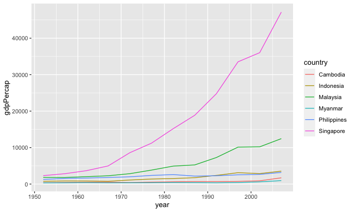

```r
asean <- c("Brunei", "Cambodia", "Laos", "Myanmar",
           "Philippines", "Indonesia", "Malaysia", "Singapore")
df %>% filter(country %in% asean) %>%
  ggplot(aes(x = year, y = gdpPercap, col = country)) + geom_line()
```

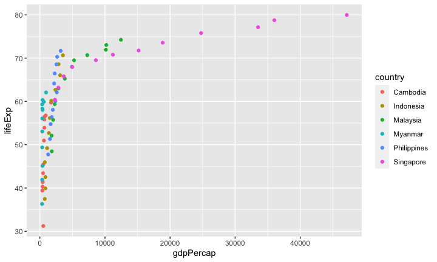

```r
df %>% filter(country %in% asean) %>%
  ggplot(aes(x = gdpPercap, y = lifeExp, col = country)) + geom_point()
```

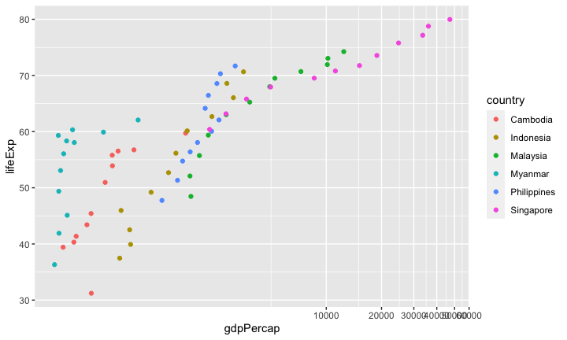

```r
df %>% filter(country %in% asean) %>%
  ggplot(aes(x = gdpPercap, y = lifeExp, col = country)) +
  geom_point() + coord_trans(x = "log10", y = "identity")
```

\(\log_{10}{100}\) = 2, \(\log_{10}{1000}\) = 3, \(\log_{10}{10000}\) = 4

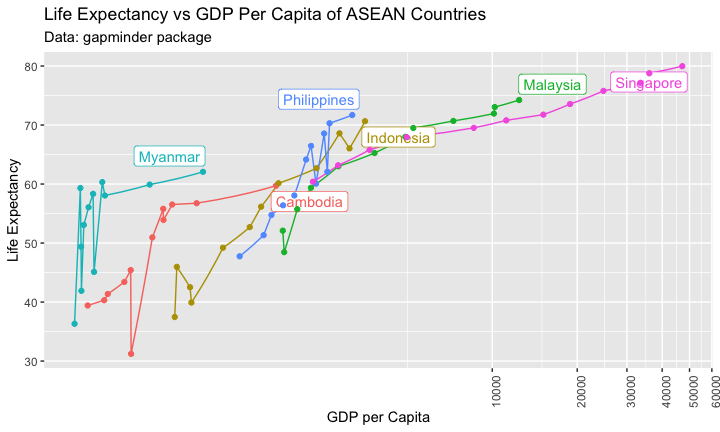

[figure not shown]

```r
library(ggrepel)
df2007 <- df %>% filter(country %in% asean, year == 2007)
df %>% filter(country %in% asean) %>%
  ggplot(aes(x = gdpPercap, y = lifeExp, col = country))+
  geom_line() + geom_label_repel(data = df2007, aes(label = country)) + geom_point()  +
  coord_trans(x = "log10", y = "identity") +
  theme(axis.text.x = element_text(angle = 90, vjust = 1, hjust=1), legend.position = "none") +
  labs(title = "Life Expectancy vs GDP Per Capita of ASEAN Countries",
       subtitle = "Data: gapminder package", x = "GDP per Capita", y = "Life Expectancy")
```

#### World Bank: World Development Indicators (WDI)

- SP.DYN.LE00.IN: Life expectancy at birth, total (years)
- NY.GDP.PCAP.KD: GDP per capita (constant 2015 US$)
- SP.POP.TOTL: Population, total

```r
df_wdi <- WDI(
  country = "all",
  indicator = c(lifeExp = "SP.DYN.LE00.IN", pop = "SP.POP.TOTL", gdpPercap = "NY.GDP.PCAP.KD")
)
```

```r
df_wdi
```

| country | iso2c | iso3c | year | lifeExp | pop | gdpPercap |
| --- | --- | --- | --- | --- | --- | --- |
| Afghanistan | AF | AFG | 1960 | 32.53500 | 8622466 | NA |
| Afghanistan | AF | AFG | 1961 | 33.06800 | 8790140 | NA |
| Afghanistan | AF | AFG | 1962 | 33.54700 | 8969047 | NA |
| Afghanistan | AF | AFG | 1963 | 34.01600 | 9157465 | NA |
| Afghanistan | AF | AFG | 1964 | 34.49400 | 9355514 | NA |
| Afghanistan | AF | AFG | 1965 | 34.95300 | 9565147 | NA |
| Afghanistan | AF | AFG | 1966 | 35.45300 | 9783147 | NA |
| Afghanistan | AF | AFG | 1967 | 35.92400 | 10010030 | NA |
| Afghanistan | AF | AFG | 1968 | 36.41800 | 10247780 | NA |
| Afghanistan | AF | AFG | 1969 | 36.91000 | 10494489 | NA |

[output cut: 9990 more lines]

```r
df_wdi_extra <- WDI(
  country = "all",
  indicator = c(lifeExp = "SP.DYN.LE00.IN", pop = "SP.POP.TOTL", gdpPercap = "NY.GDP.PCAP.KD"),
  extra = TRUE
)
```

```r
df_wdi_extra
```

| country | iso2c | iso3c | year | status | lastupdated | lifeExp | pop | gdpPercap | region | capital | longitude | latitude | income | lending |
| --- | --- | --- | --- | --- | --- | --- | --- | --- | --- | --- | --- | --- | --- | --- |
| Afghanistan | AF | AFG | 1993 | NA | 2022-12-22 | 51.46600 | 14003760 | NA | South Asia | Kabul | 69.17610 | 34.522800 | Low income | IDA |
| Afghanistan | AF | AFG | 1997 | NA | 2022-12-22 | 53.63400 | 17788819 | NA | South Asia | Kabul | 69.17610 | 34.522800 | Low income | IDA |
| Afghanistan | AF | AFG | 1994 | NA | 2022-12-22 | 51.49500 | 15455555 | NA | South Asia | Kabul | 69.17610 | 34.522800 | Low income | IDA |
| Afghanistan | AF | AFG | 1995 | NA | 2022-12-22 | 52.54400 | 16418912 | NA | South Asia | Kabul | 69.17610 | 34.522800 | Low income | IDA |
| Afghanistan | AF | AFG | 2001 | NA | 2022-12-22 | 55.79800 | 19688632 | NA | South Asia | Kabul | 69.17610 | 34.522800 | Low income | IDA |
| Afghanistan | AF | AFG | 1998 | NA | 2022-12-22 | 52.94300 | 18493132 | NA | South Asia | Kabul | 69.17610 | 34.522800 | Low income | IDA |
| Afghanistan | AF | AFG | 1999 | NA | 2022-12-22 | 54.84600 | 19262847 | NA | South Asia | Kabul | 69.17610 | 34.522800 | Low income | IDA |
| Afghanistan | AF | AFG | 2007 | NA | 2022-12-22 | 59.11100 | 25903301 | 429.4125 | South Asia | Kabul | 69.17610 | 34.522800 | Low income | IDA |
| Afghanistan | AF | AFG | 2008 | NA | 2022-12-22 | 59.85200 | 26427199 | 437.4200 | South Asia | Kabul | 69.17610 | 34.522800 | Low income | IDA |
| Afghanistan | AF | AFG | 1980 | NA | 2022-12-22 | 39.61800 | 12486631 | NA | South Asia | Kabul | 69.17610 | 34.522800 | Low income | IDA |

[output cut: 9990 more lines]